# HIV and Medicaid Expansion

Data Prep

Author

Mike Aguilar

Published

August 10, 2025

# Data

## Data Source

- Use the following to cite data included in this download:
- Global Burden of Disease Collaborative Network.
- Global Burden of Disease Study 2021 (GBD 2021) Results.
- Seattle, United States: Institute for Health Metrics and Evaluation (IHME), 2022.
- Available from https://vizhub.healthdata.org/gbd-results/.

Specifications of data pull

- GBD Estimate: Cause of death or injury
- Measure: Deaths, DALYs, YLDs, YLL, Prevalence, Incidence, Maternal Mortality Ratio
- Metric: Number, Percent, Rate
- Cause: HIV/AIDS
- Location: U.S and each state
- Age: All available age buckets
- Sex: Male, Female
- Years: 1980 through 2021

Metric Definitions

- https://view.officeapps.live.com/op/view.aspx?src=https%3A%2F%2Fwww.healthdata.org%2Fsites%2Fdefault%2Ffiles%2F2024-05%2FIHME_GBD_2021_A3_MEASURE_METRIC_DEFINITIONS_Y2024M05D15.XLSX&wdOrigin=BROWSELINK

Note

- Apparently the students said the data download process was very difficult. I disagree. I put in a request via the site. It took overnight to run.
- I then had several zip folders. I had to unzip each one then load.
- Not terribly difficult.

## Load

Loading all 7 csv files and stack into a single long dataframe.

## What fields are here?

```
 [1] "measure_id"    "measure_name"  "location_id"   "location_name"
 [5] "sex_id"        "sex_name"      "age_id"        "age_name"
 [9] "cause_id"      "cause_name"    "metric_id"     "metric_name"
[13] "year"          "val"           "upper"         "lower"
```

### Measure

```
[1] 1 2 3 4 5 6
```

```
[1] "Deaths"
[2] "DALYs (Disability-Adjusted Life Years)"
[3] "YLDs (Years Lived with Disability)"
[4] "YLLs (Years of Life Lost)"
[5] "Prevalence"
[6] "Incidence"
```

### Location

```
 [1] 102 530 537 547 545 554 523 528 570 544 524 538 562 561 571 548 531 564 555
[20] 529 532 546 563 557 573 556 566 526 533 572 525 540 565 552 549 550 539 527
[39] 559 542 551 536 541 535 569 534 543 558 567 560 553 568
```

```
 [1] "United States"        "Delaware"             "Indiana"
 [4] "Mississippi"          "Michigan"             "New Mexico"
 [7] "Alabama"              "Colorado"             "Washington"
[10] "Massachusetts"        "Alaska"               "Iowa"
[13] "Rhode Island"         "Pennsylvania"         "West Virginia"
[16] "Missouri"             "District of Columbia" "South Dakota"
[19] "New York"             "Connecticut"          "Florida"
[22] "Minnesota"            "South Carolina"       "North Dakota"
[25] "Wyoming"              "North Carolina"       "Texas"
[28] "Arkansas"             "Georgia"              "Wisconsin"
[31] "Arizona"              "Kentucky"             "Tennessee"
[34] "New Hampshire"        "Montana"              "Nebraska"
[37] "Kansas"               "California"           "Oklahoma"
[40] "Maine"                "Nevada"               "Illinois"
[43] "Louisiana"            "Idaho"                "Virginia"
[46] "Hawaii"               "Maryland"             "Ohio"
[49] "Utah"                 "Oregon"               "New Jersey"
[52] "Vermont"
```

### Sex

```
[1] 1 2
```

```
[1] "Male"   "Female"
```

### Age

```
 [1]   1   6   7   8   9  10  11  12  13  14  15  16  17  18  19  20  21  22  23
[20]  24  25  26  27  28  30  31  32  34  37  39  41 157 158 159 160 162 169 197
[39] 228 232 234 235 238 243 284 388 389 420   2   3  42
```

```
 [1] "<5 years"         "5-9 years"        "10-14 years"      "15-19 years"
 [5] "20-24 years"      "25-29 years"      "30-34 years"      "35-39 years"
 [9] "40-44 years"      "45-49 years"      "50-54 years"      "55-59 years"
[13] "60-64 years"      "65-69 years"      "70-74 years"      "75-79 years"
[17] "80+ years"        "All ages"         "5-14 years"       "15-49 years"
[21] "50-69 years"      "70+ years"        "Age-standardized" "<1 year"
[25] "80-84 years"      "85-89 years"      "90-94 years"      "2-4 years"
[29] "20+ years"        "0-14 years"       "50-74 years"      "25+ years"
[33] "<20 years"        "10-24 years"      "85+ years"        "10-19 years"
[37] "10 - 54 years"    "15-39 years"      "55+ years"        "65-74 years"
[41] "75+ years"        "95+ years"        "12-23 months"     "75-84 years"
[45] "20-54 years"      "1-5 months"       "6-11 months"      "<70 years"
[49] "0-6 days"         "7-27 days"        "<28 days"
```

### Cause

```
[1] 298
```

```
[1] "HIV/AIDS"
```

### Metric

```
[1] 1 2 3
```

```
[1] "Number"  "Percent" "Rate"
```

### Year

```
 [1] 1980 1981 1982 1983 1984 1985 1986 1987 1988 1989 1990 1991 1992 1993 1994
[16] 1995 1996 1997 1998 1999 2000 2001 2002 2003 2004 2005 2006 2007 2008 2009
[31] 2010 2011 2012 2013 2014 2015 2016 2017 2018 2019 2020 2021
```

### Policy Change

Let’s add in dates when policy change occurred.

** I don’t know the exact date. All I have are the groups from the students’ presentation. We MIGHT use those groups, but I’d like to test that myself **

| location_name | expansion_year | year |
| --- | --- | --- |
| Alabama | 0 | 1980 |
| Alabama | 0 | 1980 |
| Alabama | 0 | 1980 |
| Alabama | 0 | 1980 |
| Alabama | 0 | 1980 |
| Alabama | 0 | 1980 |
| Alabama | 0 | 1980 |
| Alabama | 0 | 1980 |
| Alabama | 0 | 1980 |
| Alabama | 0 | 1980 |

[output cut: 9990 more lines]

```
              Alaska              Arizona             Arkansas
                2015                 2014                 2014
          California             Colorado          Connecticut
                2014                 2014                 2014
            Delaware District of Columbia               Hawaii
                2014                 2014                 2014
               Idaho             Illinois              Indiana
                2020                 2014                 2015
                Iowa             Kentucky            Louisiana
                2014                 2014                 2016
               Maine             Maryland        Massachusetts
                2019                 2014                 2014
            Michigan            Minnesota             Missouri
                2014                 2014                 2021
             Montana             Nebraska               Nevada
                2016                 2020                 2014
       New Hampshire           New Jersey           New Mexico
                2014                 2014                 2014
            New York       North Carolina         North Dakota
                2014                 2023                 2014
                Ohio             Oklahoma               Oregon
                2014                 2021                 2014
        Pennsylvania         Rhode Island         South Dakota
                2015                 2014                 2023
                Utah              Vermont             Virginia
                2020                 2014                 2019
          Washington        West Virginia
                2014                 2014
```

So expansion year could be year, 0 (never switched), or NA (for U.S.)

# Clean

## Count missing

Let’s count i) entered as blank, ii) entered as NA, iii) entered as NaN

```
 location_name     measure_id   measure_name    location_id         sex_id
             0              0              0              0              0
      sex_name         age_id       age_name       cause_id     cause_name
             0              0              0              0              0
     metric_id    metric_name           year            val          upper
             0              0              0              0              0
         lower expansion_year
             0          62704
```

No missing data. Don’t worry about expansion_year since those relate to aggregate U.S. that we created.

|  | location_name | measure_id | measure_name | location_id | sex_id | sex_name | age_id | age_name | cause_id | cause_name | metric_id | metric_name | year | val | upper | lower | expansion_year |
| --- | --- | --- | --- | --- | --- | --- | --- | --- | --- | --- | --- | --- | --- | --- | --- | --- | --- |
| 1 | Alabama | 1 | Deaths | 523 | 2 | Female | 21 | 80+ years | 298 | HIV/AIDS | 1 | Number | 1980 | 0 | 0 | 0 | 0 |
| 2 | Alabama | 1 | Deaths | 523 | 1 | Male | 21 | 80+ years | 298 | HIV/AIDS | 2 | Percent | 1980 | 0 | 0 | 0 | 0 |
| 3 | Alabama | 1 | Deaths | 523 | 2 | Female | 21 | 80+ years | 298 | HIV/AIDS | 2 | Percent | 1980 | 0 | 0 | 0 | 0 |
| 4 | Alabama | 1 | Deaths | 523 | 1 | Male | 21 | 80+ years | 298 | HIV/AIDS | 3 | Rate | 1980 | 0 | 0 | 0 | 0 |
| 5 | Alabama | 1 | Deaths | 523 | 2 | Female | 21 | 80+ years | 298 | HIV/AIDS | 3 | Rate | 1980 | 0 | 0 | 0 | 0 |
| 6 | Alabama | 1 | Deaths | 523 | 1 | Male | 22 | All ages | 298 | HIV/AIDS | 1 | Number | 1980 | 0 | 0 | 0 | 0 |

But there are zero values. Is that actually 0, or is “missing” coded as 0?

Let’s count observations by year and measure

```
                                        year
measure_name                              1980  1981  1982  1983  1984  1985
  DALYs (Disability-Adjusted Life Years)     0     0     0     0     0     0
  Deaths                                 14768 14768 14768 14768 14768 14768
  Incidence                                  0     0     0     0     0     0
  Prevalence                                 0     0     0     0     0     0
  YLDs (Years Lived with Disability)         0     0     0     0     0     0
  YLLs (Years of Life Lost)              14768 14768 14768 14768 14768 14768
                                        year
measure_name                              1986  1987  1988  1989  1990  1991
  DALYs (Disability-Adjusted Life Years)     0     0     0     0 15704 15704
  Deaths                                 14768 14768 14768 14768 14768 14768
  Incidence                                  0     0     0     0 15808 15808
  Prevalence                                 0     0     0     0 15808 15808
  YLDs (Years Lived with Disability)         0     0     0     0 15808 15808
  YLLs (Years of Life Lost)              14768 14768 14768 14768 14768 14768
                                        year
measure_name                              1992  1993  1994  1995  1996  1997
  DALYs (Disability-Adjusted Life Years) 15704 15704 15704 15704 15704 15704
  Deaths                                 14768 14768 14768 14768 14768 14768
  Incidence                              15808 15808 15808 15808 15808 15808
  Prevalence                             15808 15808 15808 15808 15808 15808
  YLDs (Years Lived with Disability)     15808 15808 15808 15808 15808 15808
  YLLs (Years of Life Lost)              14768 14768 14768 14768 14768 14768
                                        year
measure_name                              1998  1999  2000  2001  2002  2003
  DALYs (Disability-Adjusted Life Years) 15704 15704 15704 15704 15704 15704
  Deaths                                 14768 14768 14768 14768 14768 14768
  Incidence                              15808 15808 15808 15808 15808 15808
  Prevalence                             15808 15808 15808 15808 15808 15808
  YLDs (Years Lived with Disability)     15808 15808 15808 15808 15808 15808
  YLLs (Years of Life Lost)              14768 14768 14768 14768 14768 14768
                                        year
measure_name                              2004  2005  2006  2007  2008  2009
  DALYs (Disability-Adjusted Life Years) 15704 15704 15704 15704 15704 15704
  Deaths                                 14768 14768 14768 14768 14768 14768
  Incidence                              15808 15808 15808 15808 15808 15808
  Prevalence                             15808 15808 15808 15808 15808 15808
  YLDs (Years Lived with Disability)     15808 15808 15808 15808 15808 15808
  YLLs (Years of Life Lost)              14768 14768 14768 14768 14768 14768
                                        year
measure_name                              2010  2011  2012  2013  2014  2015
  DALYs (Disability-Adjusted Life Years) 15704 15704 15704 15704 15704 15704
  Deaths                                 14768 14768 14768 14768 14768 14768
  Incidence                              15808 15808 15808 15808 15808 15808
  Prevalence                             15808 15808 15808 15808 15808 15808
  YLDs (Years Lived with Disability)     15808 15808 15808 15808 15808 15808
  YLLs (Years of Life Lost)              14768 14768 14768 14768 14768 14768
                                        year
measure_name                              2016  2017  2018  2019  2020  2021
  DALYs (Disability-Adjusted Life Years) 15704 15704 15704 15704 15704 15704
  Deaths                                 14768 14768 14768 14768 14768 14768
  Incidence                              15808 15808 15808 15808 15808 15808
  Prevalence                             15808 15808 15808 15808 15808 15808
  YLDs (Years Lived with Disability)     15808 15808 15808 15808 15808 15808
  YLLs (Years of Life Lost)              14768 14768 14768 14768 14768 14768
```

This table could suggest 1) the first DALYs wasn’t until 1990 or 2) DALYs were 0 for all states/sexes/ages, etc.. until 1990. No way it’s #2.

So let’s check deaths. Were the 14768 observations in 1980 valid?

```
                           metric_name
measure_name                Number Percent Rate
  Deaths                      4888    4888 4992
  YLLs (Years of Life Lost)   4888    4888 4992
```

This suggests that we only have Deaths and YLLs in 1980. That matches the table above. Good. But are they valid?

Let me filter on 1980 and only values that are = 0.

```
                           metric_name
measure_name                Number Percent Rate
  Deaths                      4888    4888 4992
  YLLs (Years of Life Lost)   4888    4888 4992
```

Exactly the same. Did I do that wrong? Let me try NOT equal to 0.

```
< table of extent 0 x 0 >
```

Wow. So that means that all of the Death and YLLs in 1980 are zero. So rather than leaving them blank, the data vendor coded them as zero.

How pervasive is this? Let’s look at all 0 entries by measure across time.

```
, , year = 1980

                                        metric_name
measure_name                             Number Percent Rate
  DALYs (Disability-Adjusted Life Years)      0       0    0
  Deaths                                   4888    4888 4992
  Incidence                                   0       0    0
  Prevalence                                  0       0    0
  YLDs (Years Lived with Disability)          0       0    0
  YLLs (Years of Life Lost)                4888    4888 4992

, , year = 1990

                                        metric_name
measure_name                             Number Percent Rate
  DALYs (Disability-Adjusted Life Years)    104     104  104
  Deaths                                      0       0    0
  Incidence                                1144    1144 1144
  Prevalence                                104     104  104
  YLDs (Years Lived with Disability)        104     104  104
  YLLs (Years of Life Lost)                   0       0    0

, , year = 1991

                                        metric_name
measure_name                             Number Percent Rate
  DALYs (Disability-Adjusted Life Years)    104     104  104
  Deaths                                      0       0    0
  Incidence                                1144    1144 1144
  Prevalence                                104     104  104
  YLDs (Years Lived with Disability)        104     104  104
  YLLs (Years of Life Lost)                   0       0    0

, , year = 1992

                                        metric_name
measure_name                             Number Percent Rate
  DALYs (Disability-Adjusted Life Years)    104     104  104
  Deaths                                      0       0    0
  Incidence                                1144    1144 1144
```

[output cut: 307 more lines]

```
  Incidence                                1144    1144 1144
  Prevalence                                 94      94   94
  YLDs (Years Lived with Disability)         94      94   94
  YLLs (Years of Life Lost)                   0       0    0

, , year = 2021

                                        metric_name
measure_name                             Number Percent Rate
  DALYs (Disability-Adjusted Life Years)     85      85   85
  Deaths                                      0       0    0
  Incidence                                1144    1144 1144
  Prevalence                                 85      85   85
  YLDs (Years Lived with Disability)         85      85   85
  YLLs (Years of Life Lost)                   0       0    0
```

Interesting. There is a big gap in the 1980’s where there are no zeros. That means that for many metrics they simply didn’t include rather than coding as zero.

There is variability by measure, so let’s focus on Deaths for now.

## Deaths

Focus on aggregate level. Whole US. All Ages. Pick one sex to start.

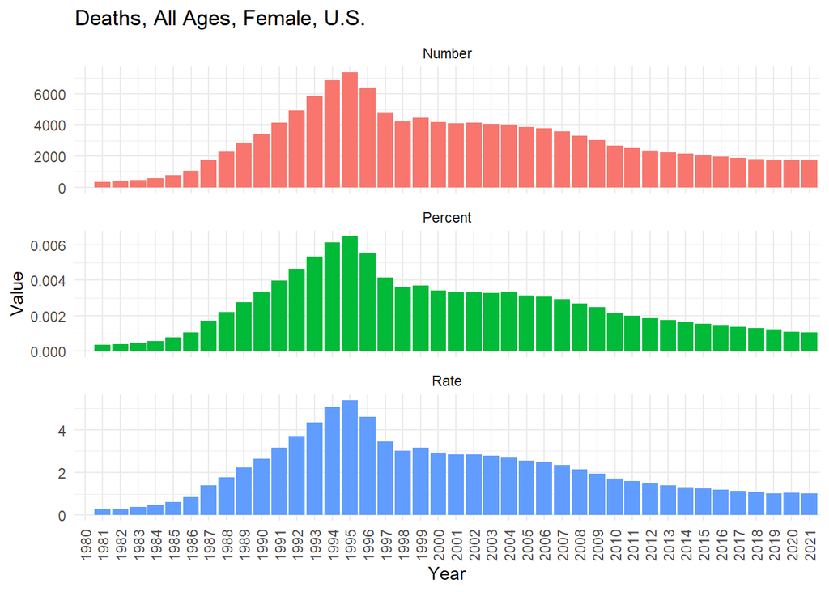

Can see that only 1980 has 0 value (i.e. missing). Good. We don’t have issue of missing observations (0’s) in the middle of the sample.

Repeat for other sex

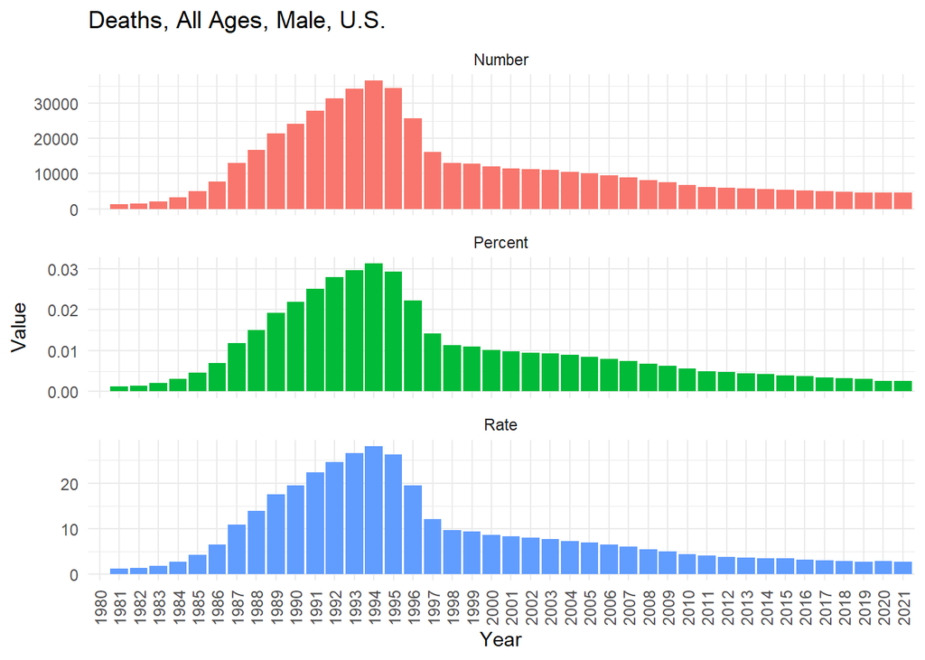

Same for men. Good.

We might still have issues for specific states or age groups. So, we need to check before running.

## Refine Age groups

We saw before that there are overlapping age groups. Using all of these could lead us to double count.

```
 [1] "80+ years"        "All ages"         "75-79 years"      "5-14 years"
 [5] "15-49 years"      "50-69 years"      "85-89 years"      "90-94 years"
 [9] "40-44 years"      "65-69 years"      "70+ years"        "Age-standardized"
[13] "<1 year"          "<20 years"        "45-49 years"      "50-54 years"
[17] "55-59 years"      "80-84 years"      "25+ years"        "10-24 years"
[21] "85+ years"        "70-74 years"      "50-74 years"      "10-19 years"
[25] "2-4 years"        "0-14 years"       "60-64 years"      "10-14 years"
[29] "15-19 years"      "20-24 years"      "<70 years"        "5-9 years"
[33] "<5 years"         "25-29 years"      "1-5 months"       "20+ years"
[37] "10 - 54 years"    "6-11 months"      "15-39 years"      "75-84 years"
[41] "20-54 years"      "12-23 months"     "95+ years"        "65-74 years"
[45] "55+ years"        "30-34 years"      "75+ years"        "35-39 years"
[49] "0-6 days"         "7-27 days"        "<28 days"
```

We don’t know population counts within each bucket. So, i) we probably want to stray away from raw Number as the metric, and ii) we want to try and pick roughly equal bucket sizes, assuming that the counts will be similar if the bind widths are similar. Let’s use the 5yr increments

```
 [1] <5 years    5-9 years   10-14 years 15-19 years 20-24 years 25-29 years
 [7] 30-34 years 35-39 years 40-44 years 45-49 years 50-54 years 55-59 years
[13] 60-64 years 65-69 years 70-74 years 75-79 years 80-84 years 85-89 years
[19] 90-94 years 95+ years   All ages
21 Levels: <5 years < 5-9 years < 10-14 years < 15-19 years < ... < All ages
```

# De Meaned

We should demean the series somehow so we can compare

- We could consider not using the entire pre treatment period to compute the avg *

Let’s compute the mean as the average for the 10yrs prior to the expansion year. e.g. if switched in 2014, then average over 2004 through 2013.

| location_name | measure_id | measure_name | location_id | sex_id | sex_name | age_id | age_name | cause_id | cause_name | metric_id | metric_name | year | val | upper | lower | expansion_year | base_mean | val_demean |
| --- | --- | --- | --- | --- | --- | --- | --- | --- | --- | --- | --- | --- | --- | --- | --- | --- | --- | --- |
| California | 1 | Deaths | 527 | 1 | Male | 1 | <5 years | 298 | HIV/AIDS | 1 | Number | 1980 | 0.000000 | 0.000000 | 0.000000 | 2014 | 3.949285 | -3.9492850 |
| California | 1 | Deaths | 527 | 1 | Male | 1 | <5 years | 298 | HIV/AIDS | 1 | Number | 1981 | 3.798084 | 3.800878 | 3.795072 | 2014 | 3.949285 | -0.1512011 |
| California | 1 | Deaths | 527 | 1 | Male | 1 | <5 years | 298 | HIV/AIDS | 1 | Number | 1982 | 4.931212 | 4.935756 | 4.926250 | 2014 | 3.949285 | 0.9819267 |
| California | 1 | Deaths | 527 | 1 | Male | 1 | <5 years | 298 | HIV/AIDS | 1 | Number | 1983 | 5.769502 | 5.774848 | 5.764076 | 2014 | 3.949285 | 1.8202174 |
| California | 1 | Deaths | 527 | 1 | Male | 1 | <5 years | 298 | HIV/AIDS | 1 | Number | 1984 | 7.197748 | 7.203701 | 7.191653 | 2014 | 3.949285 | 3.2484630 |
| California | 1 | Deaths | 527 | 1 | Male | 1 | <5 years | 298 | HIV/AIDS | 1 | Number | 1985 | 10.242202 | 10.251243 | 10.232105 | 2014 | 3.949285 | 6.2929169 |

Correct.

# Units on Deaths, Number????

- Tristan found papers suggesting that deaths are reported in millions and rates per 100K.
- I found information here: https://view.officeapps.live.com/op/view.aspx?src=https%3A%2F%2Fwww.healthdata.org%2Fsites%2Fdefault%2Ffiles%2F2024-05%2FIHME_GBD_2021_A3_MEASURE_METRIC_DEFINITIONS_Y2024M05D15.XLSX&wdOrigin=BROWSELINK suggesting that Deaths is “Number of deaths in the population”, not millions. It did confirm death rates per 100K.
- Let’s look at California Deaths All ages, Male, 2021 pulled directly from the source data.
- Number = 591.5 (matches my datapp, implying that I processed the info correctly)
- Rate = 3.01 (matches my datapp, implying that I processed the info correctly)
- Consider Rate = (Deaths / Population) *100,000
- Population = Deaths/Rate * 100,000
- Implied Population if we use Number of deaths = 591.5/3.01 * 100,000 = 19,651,100
- Implied Population if we use Number reported in mlns = 591.5 * 1000000 /3.01 * 100000 = 19.6 trln !?!?!?
- So, Number can’t be in millions.
- But even Number of deaths reported in raw units can’t be correct since CA population in 2021 was 39,142,565 (source: FRED CAPOP)
- What i the world am I doing wrong????

# Save

The raw data is rather large. Let me save only the clean data file so that I can put this on shiny apps free tier.